# Spatial Ecology and Macroecology

Practical - Week 3

Elisa Padulosi

padulosi@fzp.czu.cz

Florencia Grattarola

grattarola@fzp.czu.cz

2026-10-19

## What are we going to see today?

We will explore the potential drivers of species distribution.

1. Data sources (climate, habitat types, land cover, socioeconomic)
2. Data download and processing
3. Visualisation/mapping
4. Correlations between predictors
5. Description of patterns (vs. biodiversity)

Exercises:

1. Peru: drivers of amphibians richness patterns 🐸
2. France: drivers of trees richness patterns 🌳

# Data sources

### worldclim.org

**WorldClim** Is a database of high spatial resolution global weather and climate data. You can download gridded weather and climate data for historical (near current) and future conditions.

[figure not shown]

### chelsa-climate.org

**CHELSA** (Climatologies at high resolution for the earth’s land surface areas) is a very high resolution (30 arc sec, ~1km) global downscaled climate data set. It includes climate layers for various time periods and variables, ranging from the Last Glacial Maximum, to the present, to several future scenarios.

[figure not shown]

### nature.com/articles/s41597-020-00599-8

A global, spatially explicit characterization of 47 **terrestrial habitat types**, as defined in the International Union for Conservation of Nature (IUCN) habitat classification scheme.

`Habitatmapping`: https://github.com/Martin-Jung/Habitatmapping

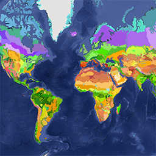

### ecoregions.appspot.com

The **RESOLVE Ecoregions** dataset, updated in 2017, offers a depiction of the 846 terrestrial ecoregions that represent our living planet.

[figure not shown]

### land.copernicus.eu/pan-european/corine-land-cover

The **CORINE** Land Cover (CLC) consists of an inventory of land cover in 44 classes (from Europe). The inventory was initiated in 1985. Updates have been produced in 2000, 2006, 2012, and 2018.

[figure not shown]

### modis.gsfc.nasa.gov

**Terra MODIS** and **Aqua MODIS** satellites are viewing the entire Earth’s surface every 1 to 2 days, acquiring data in 36 spectral bands or groups of wavelengths.

`MODIStsp`: https://github.com/ropensci/MODIStsp/ (**NOT WORKING ATM**)

[figure not shown]

### sedac.ciesin.columbia.edu

**SEDAC**, the Socioeconomic Data and Applications Center, focuses on human interactions in the environment and seeks to develop and operate applications that support the integration of socioeconomic and earth science data.

# EXCERCISE Peru: drivers of amphibians richness

## Peru: drivers of amphibians richness 🐸

Steps:

1. Get a map of Peru
2. Get 5 different drivers (`raster`)
3. Process all the layers to the same resolution and the extent of Peru
4. Visualise predictors
5. Calculate the correlation between the different predictors (and compare with biodiversity)

# Some preparation before starting to code

## Biodiversiy data download

Please download the following file and store it on you `data` folder:

- `amphibians_grid.rds`

To create this file, I followed steps from the previous practicals. First I downloaded and cleaned data from GBIF, and then I created a grid cell for Peru of 50 x 50 km.

Check [`download_amphibiansPE_data_from_GBIF.R`](https://github.com/petrkeil/Spatial-Ecology-and-Macroecology/blob/main/Practical_classes/Week3_predictors/download_amphibiansPE_data_from_GBIF.R) to see how the data were downloaded, and [`preparing_amphibiansPE_grid.R`](https://github.com/petrkeil/Spatial-Ecology-and-Macroecology/blob/main/Practical_classes/Week3_predictors/preparing_amphibiansPE_grid.R) to see how I created the grid

## Biodiversiy data download

This is how the data look like

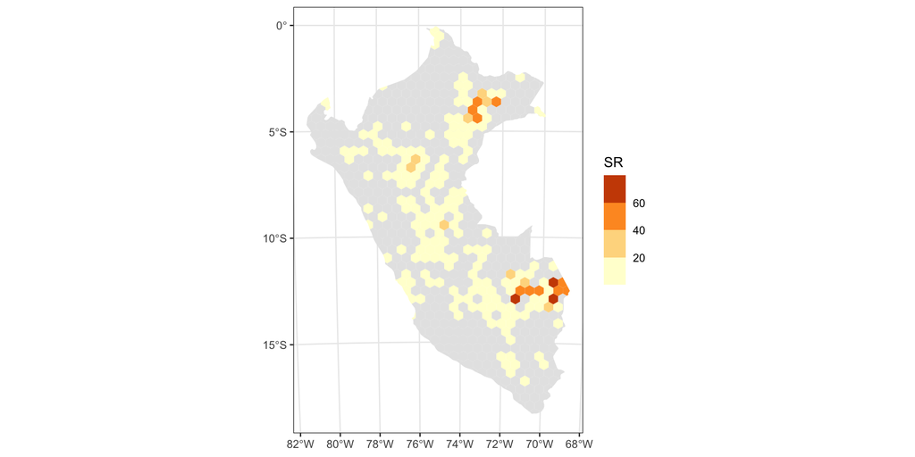

## Packages

We will use `sf`, `rnaturalearth`, and `tidyverse`.

```r
library(pacman)
pacman::p_load(sf,  # Manage spatial data as simple features dataframes
               rnaturalearth, # useful base maps
               tidyverse) # install the package if you haven't already

sf_use_s2(FALSE) # switch spherical geometry off
```

## Packages

We will also use `terra` to manage and analyse rasters and vectors, `tmap` for plotting maps, `geodata` to get multiple sources of spatial data, and `MODIStsp` for processing time series from MODIS data.

```r
pacman::p_load(terra, # Work with rasters and vectorial spatial data
               tmap, # Cool maps
               GGally, # Cool correlation maps
               geodata, # Get data from multiple sources
               MODIStsp) # Get data from MODIS
```

## Peru: drivers of amphibians richness 🐸

1. Get a map of Peru

We will need,

- The polygon and spatial extent of Peru
- A planar projection of the area.

## Peru: drivers of amphibians richness 🐸

1. Get a map of Peru

```r
peru <- ne_countries(
  country = "Peru",
  returnclass = "sf" # We want an object of class sf
)
```

Let’s see how it looks.

## Peru: drivers of amphibians richness 🐸

1. Get a map of Peru

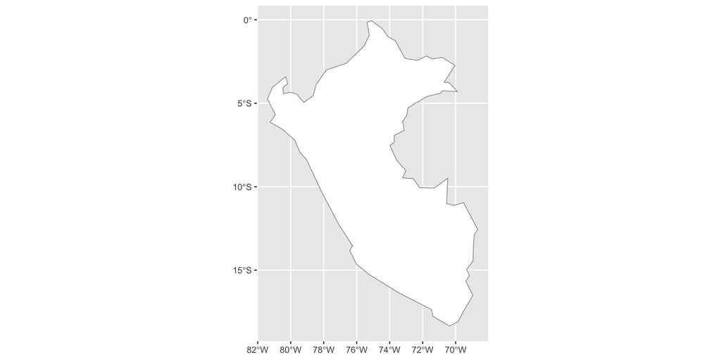

```r
ggplot() +
  geom_sf(data=peru, fill='white') +
  coord_sf()
```

## Peru: drivers of amphibians richness 🐸

1. Get a map of Peru

To get a planar projection of the area (visit https://projectionwizard.org/).

```r
proj_peru <- 'PROJCS["ProjWiz_Custom_Transverse_Cylindrical_Equal_Area",
 GEOGCS["GCS_WGS_1984",
  DATUM["D_WGS_1984",
   SPHEROID["WGS_1984",6378137.0,298.257223563]],
  PRIMEM["Greenwich",0.0],
  UNIT["Degree",0.0174532925199433]],
 PROJECTION["Transverse_Cylindrical_Equal_Area"],
 PARAMETER["False_Easting",0.0],
 PARAMETER["False_Northing",0.0],
 PARAMETER["Central_Meridian",-74.7949219],
 PARAMETER["Scale_Factor",1.0],
 PARAMETER["Latitude_Of_Origin",0.0],
 UNIT["Meter",1.0]]'
```

We will use it later.

## Peru: drivers of amphibians richness 🐸

2. Get 5 different drivers (`raster`)
- Annual mean temperature (**WorldClim BIO1**)
- Annual precipitation (**WorldClim BIO12**)
- Elevation (**SRTM**)
- Land-cover (**MODIS Terra MCD12Q1**)
- Human footprint index (**SEDAC**)

## Peru: drivers of amphibians richness 🐸

2. Get 5 different drivers (`raster`)

When working with rasters, there are three basic procedures we can recommend you:

1. **Crop**: Cut the rasters to the geographic `extent` you need. This is a square cut.
2. **Reproject**: Make sure that all your rasters are on the same `projection`. But be aware that by reprojecting, you are introducing an additional source of error.
3. **Mask**: Set to `NA` all the cells outside your polygon(s) of interest.

## Peru: drivers of amphibians richness 🐸

2. Get 5 different drivers (`raster`)

We will create a variable with the spatial extent of Peru to use it to crop the raster data.

```r
round(st_bbox(peru),0) # Check the extent of the country (round values)
```

```
xmin ymin xmax ymax
 -81  -18  -69    0
```

```r
round(st_bbox(peru),0) + c(-1,-1,1,1) #This way we add space around the country
```

```
xmin ymin xmax ymax
 -82  -19  -68    1
```

Now let’s create an object with the extent.

```r
extent <- round(st_bbox(peru),0) + c(-1,-1,1,1) # Bounding box plus 1 degree
```

## Peru: drivers of amphibians richness 🐸

2. Get 5 different drivers (`raster`)

We will also set the path were we are going to save data.

```r
geodata_path("data/")
```

This is required to use the package `geodata`. From now on, every time you try to get a dataset with `geodata` functions, the package will check if the data already exists in your data folder and load it from there.

## Peru: drivers of amphibians richness 🐸

2. Get 5 different drivers (`raster`): climate

Let’s first download the **WorldClim** data (version 2.1 climate data for 1970-2000):

- Annual mean temperature (`bio1`)
- Annual precipitation (`bio12`)

You can download these data from https://www.worldclim.org/data/worldclim21.html  
or use the package `geodata`.

## Peru: drivers of amphibians richness 🐸

2. Get 5 different drivers (`raster`): climate

We will use the function `worldclim_country()` from `geodata`.

```r
tavg <- worldclim_country(var = "tavg",country = "PER") # PER is the three letters ISO code for PERU
tavg <- crop(tavg, extent)
```

```r
tavg
```

```
class       : SpatRaster
size        : 2220, 1560, 12  (nrow, ncol, nlyr)
resolution  : 0.008333333, 0.008333333  (x, y)
extent      : -81.5, -68.5, -18.5, 0  (xmin, xmax, ymin, ymax)
coord. ref. : lon/lat WGS 84 (EPSG:4326)
source      : PER_wc2.1_30s_tavg.tif
names       : PER_w~avg_1, PER_w~avg_2, PER_w~avg_3, PER_w~avg_4, PER_w~avg_5, PER_w~avg_6, ...
min values  :        -5.4,        -5.4,        -5.2,        -5.8,        -6.9,        -8.6, ...
max values  :        27.4,        27.3,        27.3,        27.3,        27.0,        26.8, ...
```

## Peru: drivers of amphibians richness 🐸

2. Get 5 different drivers (`raster`): climate

Now get the precipitation data from Worldclim.

```r
bio <- worldclim_country(var = "bio", country = "PER")
```

And filter `bio12`.

```r
prec <- bio$wc2.1_30s_bio_12
```

```r
prec <- crop(prec, extent)
prec
```

```
class       : SpatRaster
size        : 2220, 1560, 1  (nrow, ncol, nlyr)
resolution  : 0.008333333, 0.008333333  (x, y)
extent      : -81.5, -68.5, -18.5, 0  (xmin, xmax, ymin, ymax)
coord. ref. : lon/lat WGS 84 (EPSG:4326)
source      : PER_wc2.1_30s_bio.tif
name        : wc2.1_30s_bio_12
min value   :                0
max value   :             6256
```

## Peru: drivers of amphibians richness 🐸

2. Get 5 different drivers (`raster`): elevation

We will use the function `elevation_30s()` from `geodata`. These data come from the Shuttle Radar Topographic Mission and are aggregated to 1km resolution.

```r
elev <- elevation_30s(country = "PER")
elev <- crop(elev, extent)
elev
```

```
class       : SpatRaster
size        : 2232, 1560, 1  (nrow, ncol, nlyr)
resolution  : 0.008333333, 0.008333333  (x, y)
extent      : -81.5, -68.5, -18.5, 0.1  (xmin, xmax, ymin, ymax)
coord. ref. : lon/lat WGS 84 (EPSG:4326)
source      : PER_elv_msk.tif
name        : PER_elv_msk
min value   :         -25
max value   :        6547
```

## Peru: drivers of amphibians richness 🐸

2. Get 5 different drivers (`raster`): land-cover

Now, let’s get the landcover data. For this we will use the package `MODIStsp`.

**`MODIStsp` has not been maintained**

The package may not be working properly.

```r
MODIStsp_get_prodnames()
```

```
  [1] "Surf_Ref_8Days_500m (M*D09A1)"
  [2] "Surf_Ref_Daily_005dg (M*D09CMG)"
  [3] "Surf_Ref_Daily_500m (M*D09GA)"
  [4] "Surf_Ref_Daily_250m (M*D09GQ)"
  [5] "Surf_Ref_8Days_250m (M*D09Q1)"
  [6] "Snow_Cov_Daily_500m (M*D10A1)"
  [7] "Snow_Cov_8-Day_500m (M*D10_A2)"
  [8] "Snow_Cov_Day_0.05Deg (M*D10C1)"
  [9] "Snow_Cov_8-Day0.05Deg CMG (M*D10C2)"
 [10] "Snow_Cov_Month_0.05Deg CMG (M*D10CM)"
 [11] "Surf_Temp_Daily_005dg (M*D11C1)"
 [12] "Surf_Temp_Daily_1Km (M*D11A1)"
 [13] "Surf_Temp_8Days_1Km (M*D11A2)"
 [14] "Surf_Temp_Daily_GridSin (M*D11B1)"
 [15] "Surf_Temp_8Days_GridSin (M*D11B2)"
```

[output cut: 109 more lines]

## Peru: drivers of amphibians richness 🐸

2. Get 5 different drivers (`raster`): land-cover

To download **MODIS** data through the NASA *http* server, we need to create a profile at https://urs.earthdata.nasa.gov/home to get a user and password.

Today, I’ll present you an example and provide you with the data already processed, but you can do this at home.

We will use the [Land Cover Type Yearly L3 Global 500m](https://lpdaac.usgs.gov/products/mcd12q1v061/), and download data for **Peru** from the year **2020**.

## Peru: drivers of amphibians richness 🐸

2. Get 5 different drivers (`raster`): land-cover

With `MODIStsp_get_prodlayers()` you can see all the layers of the product:

```r
MODIStsp_get_prodlayers("MCD12Q1", prodver = "061")$bandnames
```

```
 [1] "LC1"                 "LC2"                 "LC3"
 [4] "LC4"                 "LC5"                 "LC_Prop1"
 [7] "LC_Prop2"            "LC_Prop3"            "LC_Prop1_Assessment"
[10] "LC_Prop2_Assessment" "LC_Prop3_Assessment" "LC_QC"
[13] "LC_LW"
```

There are five different land cover classification schemes, we will be using the primary land cover scheme (**LC1**) which identifies 17 classes defined by the [IGBP](http://www.igbp.net/) (International Geosphere-Biosphere Programme), including 11 natural vegetation classes, 3 human-altered classes, and 3 non-vegetated classes.

## Peru: drivers of amphibians richness 🐸

2. Get 5 different drivers (`raster`): land-cover

We will use the function `MODIStsp()` to download data:

```r
MODIStsp(
  ...,
  gui = TRUE,
  out_folder = NULL,
  out_folder_mod = NULL,
  opts_file = NULL,
  selprod = NULL,
  prod_version = NULL,
  bandsel = NULL,
  quality_bandsel = NULL,
  indexes_bandsel = NULL,
  sensor = NULL,
  download_server = NULL,
  downloader = NULL,
  user = NULL,
  password = NULL,
  download_range = NULL,
  start_date = NULL,
  end_date = NULL,
  spatmeth = NULL,
  start_x = NULL,
  end_x = NULL,
  start_y = NULL,
  end_y = NULL,
  bbox = NULL,
  spafile = NULL,
  out_projsel = NULL,
  output_proj = NULL,
  out_res_sel = NULL,
  out_res = NULL,
  resampling = NULL,
  reprocess = NULL,
  delete_hdf = NULL,
  nodata_change = NULL,
  scale_val = NULL,
  ts_format = NULL,
  out_format = NULL,
  compress = NULL,
  test = NULL,
  n_retries = 5,
  verbose = TRUE,
  parallel = TRUE
)
```

## Peru: drivers of amphibians richness 🐸

2. Get 5 different drivers (`raster`): land-cover

```r
MODIStsp(
  gui = FALSE,
  out_folder = "data/",
  out_folder_mod = "data/",
  selprod = "LandCover_Type_Yearly_500m (MCD12Q1)",
  prod_version = "061",
  bandsel = "LC1",
  sensor = "Terra",
  user = your_user, # your username for NASA http server
  password = your_pass, # your password for NASA http server
  start_date = "2020.01.01",
  end_date = "2020.12.31",
  verbose = TRUE,
  bbox = extent, # bbox covering Peru
  spatmeth = "bbox",
  out_format = "GTiff",
  compress = "LZW",
  out_projsel = "User Defined",
  output_proj = 4326,
  delete_hdf = TRUE,
  parallel = TRUE
)
```

## Peru: drivers of amphibians richness 🐸

2. Get 5 different drivers (`raster`): land-cover

Let’s read the layer and process it.

```r
land <- rast("data/MCD12Q1.061_LC_Type1_doy2020001_aid0001.tif")
land <- crop(land , extent)
land
```

```
class       : SpatRaster
size        : 4800, 3360, 1  (nrow, ncol, nlyr)
resolution  : 0.004166667, 0.004166667  (x, y)
extent      : -82, -68, -19, 1  (xmin, xmax, ymin, ymax)
coord. ref. : lon/lat WGS 84 (EPSG:4326)
source(s)   : memory
varname     : MCD12Q1.061_LC_Type1_doy2020001_aid0001
name        : MCD12Q1.061_LC_Type1_doy2020001_aid0001
min value   :                                       1
max value   :                                      17
```

## Peru: drivers of amphibians richness 🐸

2. Get 5 different drivers (`raster`): anthropogenic

Again using the package `geodata`.

```r
footp <- footprint(year = 2009)
footp <- crop(footp, extent)
footp
```

```
class       : SpatRaster
size        : 2400, 1680, 1  (nrow, ncol, nlyr)
resolution  : 0.008333333, 0.008333333  (x, y)
extent      : -82, -68, -19, 1  (xmin, xmax, ymin, ymax)
coord. ref. : lon/lat WGS 84 (EPSG:4326)
source(s)   : memory
varname     : wildareas-v3-2009-human-footprint_geo
name        : wildareas-v3-2009-human-footprint
min value   :                                 0
max value   :                                46
```

## Peru: drivers of amphibians richness 🐸

3. Process all the layers to the same resolution and the extent of Peru

Rasters should have the same spatial extent and resolution… If they don’t match… what should we do?

```r
compareGeom(tavg, prec, elev, footp, land, stopOnError = F, messages = T, res = T)
```

```
[1] FALSE
```

## Peru: drivers of amphibians richness 🐸

3. Process all the layers to the same resolution and the extent of Peru

```r
st_bbox(tavg)
```

```
 xmin  ymin  xmax  ymax
-81.5 -18.5 -68.5   0.0
```

```r
st_bbox(prec)
```

```
 xmin  ymin  xmax  ymax
-81.5 -18.5 -68.5   0.0
```

```r
st_bbox(elev)
```

```
 xmin  ymin  xmax  ymax
-81.5 -18.5 -68.5   0.1
```

```r
st_bbox(footp)
```

```
xmin ymin xmax ymax
 -82  -19  -68    1
```

```r
st_bbox(land)
```

```
xmin ymin xmax ymax
 -82  -19  -68    1
```

```r
#Compare with the country extent
st_bbox(peru)
```

```
       xmin        ymin        xmax        ymax
-81.4109426 -18.3479754 -68.6650797  -0.0572055
```

## Peru: drivers of amphibians richness 🐸

3. Process all the layers to the same resolution and the extent of Peru

We will use the package `terra` to process the rasters.  
First we need to create a new raster to use as a **template**.

```r
r <- rast(res = 0.5, # target cell size (0.5 degree)
          ext = extent, # or even `ext(vect(peru))`
          crs = "epsg:4326") # projection of our rasters
r
```

```
class       : SpatRaster
size        : 40, 28, 1  (nrow, ncol, nlyr)
resolution  : 0.5, 0.5  (x, y)
extent      : -82, -68, -19, 1  (xmin, xmax, ymin, ymax)
coord. ref. : lon/lat WGS 84 (EPSG:4326)
```

## Peru: drivers of amphibians richness 🐸

3. Process all the layers to the same resolution and the extent of Peru

We will `resample()` all of the rasters to our target resolution.

```r
tavg <- resample(tavg, r, method = "bilinear") # for continuous data!
prec <- resample(prec, r, method = "bilinear")
elev <- resample(elev, r, method = "bilinear")
footp <- resample(footp, r, method = "bilinear")
land <- resample(land, r, method = "near")  # for categorical data!
```

And we can compare the rasters after resampling.

```r
compareGeom(tavg, prec, elev, footp, land, stopOnError = F, messages = T, res = T)
```

```
[1] TRUE
```

## Peru: drivers of amphibians richness 🐸

3. Process all the layers to the same resolution and the extent of Peru

And finally we will use `mask()` to intersect the layer with Peru.

```r
tavg <- mask(tavg, vect(peru))
prec <- mask(prec, vect(peru))
elev <- mask(elev, vect(peru))
footp <- mask(footp, vect(peru))
land <- mask(land, vect(peru))
```

## Peru: drivers of amphibians richness 🐸

3. Process all the layers to the same resolution and the extent of Peru

```r
names(tavg)
```

```
 [1] "PER_wc2.1_30s_tavg_1"  "PER_wc2.1_30s_tavg_2"  "PER_wc2.1_30s_tavg_3"
 [4] "PER_wc2.1_30s_tavg_4"  "PER_wc2.1_30s_tavg_5"  "PER_wc2.1_30s_tavg_6"
 [7] "PER_wc2.1_30s_tavg_7"  "PER_wc2.1_30s_tavg_8"  "PER_wc2.1_30s_tavg_9"
[10] "PER_wc2.1_30s_tavg_10" "PER_wc2.1_30s_tavg_11" "PER_wc2.1_30s_tavg_12"
```

```r
tavg <- mean(tavg)
prec <- mean(prec)
```

Now, we are ready!

## Peru: drivers of amphibians richness 🐸

4. Visualise predictors

We will use the package `tmap`.

```r
tmap_mode(mode = "view")
```

## Peru: drivers of amphibians richness 🐸

Annual mean temperature (WorldClim BIO1)

[interactive chart not shown]

## Peru: drivers of amphibians richness 🐸

Annual Precipitation (WorldClim BIO12)

[interactive chart not shown]

## Peru: drivers of amphibians richness 🐸

[interactive chart not shown]

## Peru: drivers of amphibians richness 🐸

4. Visualise predictors

Land-cover (MODIS Terra MCD12Q1). We need to make sure values are factors.

```r
names(land)
```

```
[1] "MCD12Q1.061_LC_Type1_doy2020001_aid0001"
```

```r
land <- as.factor(land$MCD12Q1.061_LC_Type1_doy2020001_aid0001)
```

## Peru: drivers of amphibians richness 🐸

4. Visualise predictors

Then we can add values to the levels.

```r
levels(land[[1]]) <- data.frame(
  ID = c(1, 2, 3, 4, 5, 6, 7, 8, 9, 10, 11, 12, 13, 14, 15, 16, 17),
  label = c(
    "Evergreen Needleleaf Forest",
    "Evergreen Broadleaf Forests",
    "Deciduous Needleleaf Forests",
    "Deciduous Broadleaf Forests",
    "Mixed Forests",
    "Closed Shrublands",
    "Open Shrublands",
    "Woody Savannas",
    "Savannas",
    "Grassslands",
    "Permanent Wetlands",
    "Croplands",
    "Urban and Built-up Lands",
    "Cropland/Natural Vegetation Mosaics",
    "Permanent Snow and Ice",
    "Barren",
    "Water Bodies"
  )
)
```

You might not have the same classes/levels at different areas. Check here the classification values: [MCD12_User_Guide_V6](https://lpdaac.usgs.gov/documents/101/MCD12_User_Guide_V6.pdf) (see page 7 Classification Legends).

## Peru: drivers of amphibians richness 🐸

Land-cover (MODIS Terra MCD12Q1)

[interactive chart not shown]

## Peru: drivers of amphibians richness 🐸

Human footprint index (SEDAC)

[interactive chart not shown]

## Peru: drivers of amphibians richness 🐸

5. Calculate the correlation between the different predictors (and compare with biodiversity)

Let’s see all the values together.

```r
predictors <- tibble(
  "tavg" = values(tavg) %>% as.vector(),
  "prec" = values(prec) %>% as.vector(),
  "elev" = values(elev) %>% as.vector(),
  "land" = values(land) %>% as.vector(),
  "footp" = values(footp) %>% as.vector()
) %>%
  mutate(
    across(everything(), ~replace_na(.x, NA))
  )
```

## Peru: drivers of amphibians richness 🐸

5. Calculate the correlation between the different predictors (and compare with biodiversity)

Let’s see all the values together.

```r
summary(predictors)
```

```
      tavg            prec               elev              land
 Min.   : 2.78   Min.   :   1.693   Min.   :  20.57   Min.   : 2.000
 1st Qu.:13.96   1st Qu.: 818.484   1st Qu.: 200.01   1st Qu.: 2.000
 Median :23.68   Median :1716.595   Median : 622.70   Median : 2.000
 Mean   :19.73   Mean   :1645.788   Mean   :1491.56   Mean   : 6.354
 3rd Qu.:25.92   3rd Qu.:2433.821   3rd Qu.:2843.70   3rd Qu.:10.000
 Max.   :26.97   Max.   :4556.751   Max.   :4690.38   Max.   :17.000
 NA's   :642     NA's   :642        NA's   :692       NA's   :608
     footp
 Min.   : 0.0035
 1st Qu.: 0.7955
 Median : 2.2689
 Mean   : 3.0466
 3rd Qu.: 5.0633
 Max.   :10.1683
 NA's   :608
```

## Peru: drivers of amphibians richness 🐸

5. Calculate the correlation between the different predictors (and compare with biodiversity)

Let’s see how these values correlate.

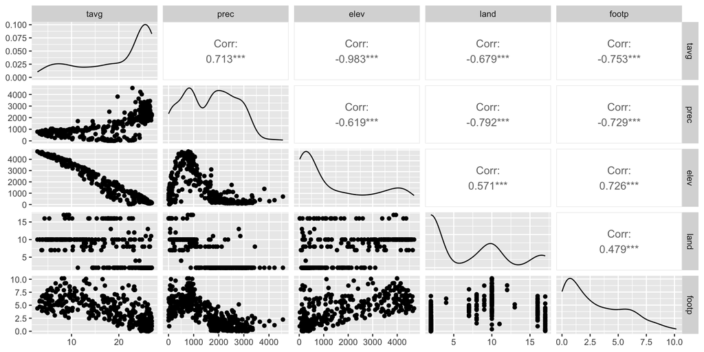

```r
GGally::ggpairs(predictors, cex = 0.1)
```

What can this plot tell you?

# EXTRA Can we see any pattern with the hotspots of amphibians species richness?

## Peru: drivers of amphibians richness 🐸

Let’s read the data, plot it and see the patterns

```r
amphibians_grid <- readRDS("data/amphibians_grid.rds") %>%
  st_transform(., 4326)
```

## Peru: drivers of amphibians richness 🐸

Let’s read the data, plot it and see the patterns

[interactive chart not shown]

## Peru: drivers of amphibians richness 🐸

Species richness vs mean annual temperature

[interactive chart not shown]

## Peru: drivers of amphibians richness 🐸

[interactive chart not shown]

## Peru: drivers of amphibians richness 🐸

Species richness vs elevation

[interactive chart not shown]

## Peru: drivers of amphibians richness 🐸

Species richness vs land-use

[interactive chart not shown]

## Peru: drivers of amphibians richness 🐸

Species richness vs human footprint

[interactive chart not shown]

## Peru: drivers of amphibians richness 🐸

1. Get a map of Peru
2. Get 5 different drivers (`raster`)
3. Process all the layers to the same resolution and the extent of Peru
4. Visualise predictors
5. Calculate the correlation between the different predictors (and compare with biodiversity)

We are done! No it’s **your turn** :)

# EXCERCISE France: drivers of trees richness

## France: drivers of trees richness patterns 🌳

1. Get a map of France
2. Get 5 different drivers (`raster`)
3. Process all the layers to the same resolution and the extent of France
4. Visualise predictors
5. Calculate the correlation between the different predictors (and compare with biodiversity)

## France: drivers of trees richness patterns 🌳

This time, you will use the following drivers:

- Temperature seasonality (**WorldClim BIO4**)
- Annual precipitation (**WorldClim BIO12**)
- Elevation (**SRTM**)
- Land-cover (**MODIS Terra MCD12Q1**)
- Human footprint index (**SEDAC**)

See the solutions at practical_week3_STUDENTS_FILE_solved.qmd.